# TD8

Charles Vin

2022-04-04

```r
library(car)
library(emmeans)
```

# Question 1

```r
df = read.csv("./MiniPONS.csv", sep=";")
head(df)
```

|  | Group | Type | Age | Right_answers | Audio_prosody | Combined_channel | Face_video | Body_video | Positive_valence | Negative_valence | Dominant | Submissive |
| --- | --- | --- | --- | --- | --- | --- | --- | --- | --- | --- | --- | --- |
| 1 | Bipolar | BD I | 47 | 40 | 9 | 11 | 9 | 11 | 18 | 22 | 23 | 17 |
| 2 | Bipolar | BD I | 49 | 49 | 13 | 13 | 11 | 12 | 24 | 25 | 24 | 25 |
| 3 | Bipolar | BD I | 45 | 43 | 9 | 11 | 13 | 10 | 21 | 22 | 24 | 19 |
| 4 | Bipolar | BD I | 53 | 44 | 10 | 10 | 12 | 12 | 25 | 19 | 24 | 20 |
| 5 | Bipolar | BD II | 50 | 50 | 14 | 13 | 11 | 12 | 23 | 27 | 23 | 27 |
| 6 | Bipolar | BD I | 31 | 54 | 13 | 14 | 14 | 13 | 28 | 26 | 26 | 28 |

# Question 2

```r
is.factor(df$Group)
```

```
[1] FALSE
```

```r
is.factor(df$Type)
```

```
[1] FALSE
```

```r
df$Group = as.factor(df$Group)
df$Type = as.factor(df$Type)
levels(df$Type)
```

```
[1] "BD I"    "BD II"   "Control" "UD"
```

```r
levels(df$Group)
```

```
[1] "Bipolar" "Control" "UD"
```

# Question 3

```r
by(df$Right_answers, df$Group, summary )
```

```
df$Group: Bipolar
   Min. 1st Qu.  Median    Mean 3rd Qu.    Max.
  28.00   42.50   46.00   45.35   49.00   56.00
------------------------------------------------------------------------------------
df$Group: Control
   Min. 1st Qu.  Median    Mean 3rd Qu.    Max.
  39.00   48.00   50.00   50.24   53.00   58.00
------------------------------------------------------------------------------------
df$Group: UD
   Min. 1st Qu.  Median    Mean 3rd Qu.    Max.
  32.00   39.00   43.00   42.72   47.00   53.00
```

```r
by(df$Right_answers, df$Group, sd )
```

```
df$Group: Bipolar
[1] 4.795104
------------------------------------------------------------------------------------
df$Group: Control
[1] 3.704569
------------------------------------------------------------------------------------
df$Group: UD
[1] 4.973343
```

On peut constater que les Bipolaire et les patients diagnostiqué UD ont en moyenne moins de bonne réponse que les sujets contrôles. De plus leurs écarts type est moins bon.

# Question 4

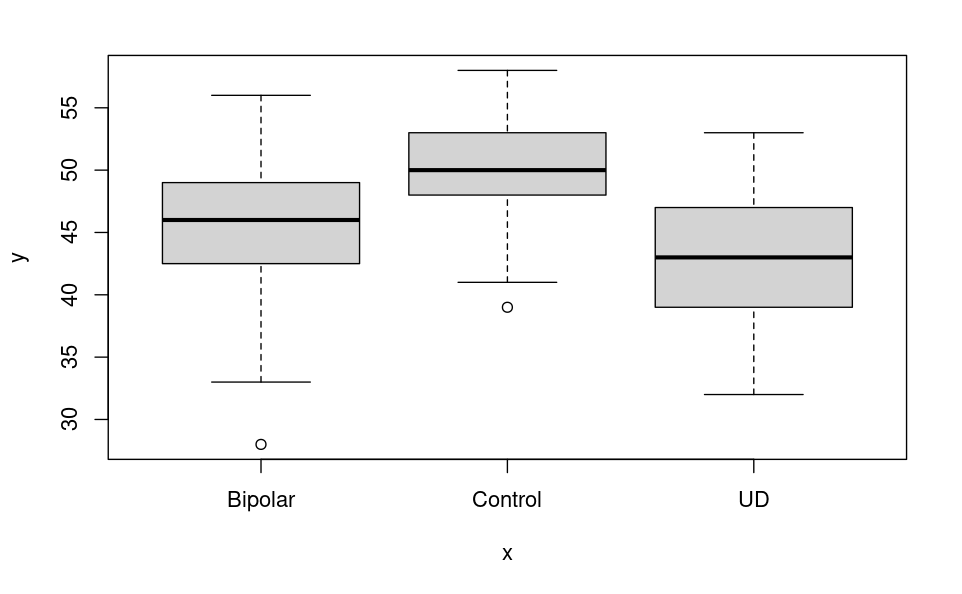

```r
plot(df$Group, df$Right_answers, type="b")
```

# Question 5

```r
df$Agec=rep(2,length(df$Group))
df$Agec[which(df$Age<40)]=1
df$Agec[which(df$Age>=60)]=3
df$Agec=as.factor(df$Agec)
levels(df$Agec)=c("<40", "40-60", ">=60")
```

# Question 6

```r
table(df$Agec, df$Group)
```

```
        Bipolar Control UD
  <40        39      39  1
  40-60      61      67 14
  >=60       19      13 24
```

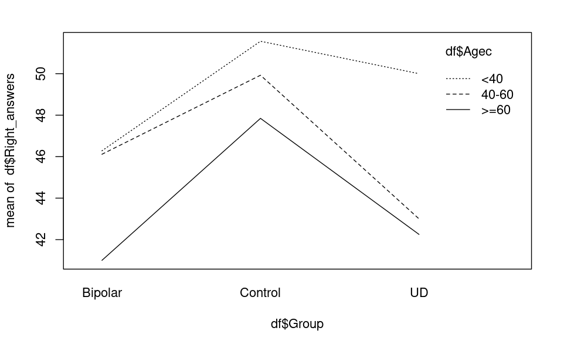

```r
interaction.plot(df$Group, df$Agec, df$Right_answers)
```

Les effectifs ne sont pas vraiment équilibré dans avec le groupe UD.

Ils pourrait avoir de l’interaction. Considérons le plus grand des modèles possibles donc avec interaction. Puis on vas regarder si le les interraction valent le coup. On vas comparer le modèle avec interaction à celui sans interaction. Si le modèle sans intéraction est mieux, on regardera ensuite si chaque facteur vaut le coup.

# Question 7

## Modèle retenu

```r
res = lm(df$Right_answers~df$Group*df$Agec)
res
```

```
Call:
lm(formula = df$Right_answers ~ df$Group * df$Agec)

Coefficients:
                 (Intercept)               df$GroupControl                    df$GroupUD
                     46.2821                        5.2821                        3.7179
                df$Agec40-60                   df$Agec>=60  df$GroupControl:df$Agec40-60
                     -0.1673                       -5.2821                       -1.4714
     df$GroupUD:df$Agec40-60   df$GroupControl:df$Agec>=60        df$GroupUD:df$Agec>=60
                     -6.8327                        1.5641                       -2.4679
```

```r
summary(res)
```

```
Call:
lm(formula = df$Right_answers ~ df$Group * df$Agec)

Residuals:
     Min       1Q   Median       3Q      Max
-13.0000  -2.8462   0.0746   2.7179  10.0000

Coefficients:
                             Estimate Std. Error t value Pr(>|t|)
(Intercept)                   46.2821     0.6659  69.504  < 2e-16 ***
df$GroupControl                5.2821     0.9417   5.609 5.06e-08 ***
df$GroupUD                     3.7179     4.2115   0.883    0.378
df$Agec40-60                  -0.1673     0.8526  -0.196    0.845
df$Agec>=60                   -5.2821     1.1634  -4.540 8.50e-06 ***
df$GroupControl:df$Agec40-60  -1.4714     1.1952  -1.231    0.219
df$GroupUD:df$Agec40-60       -6.8327     4.3881  -1.557    0.121
df$GroupControl:df$Agec>=60    1.5641     1.7684   0.884    0.377
df$GroupUD:df$Agec>=60        -2.4679     4.4008  -0.561    0.575
---
Signif. codes:  0 ‘***’ 0.001 ‘**’ 0.01 ‘*’ 0.05 ‘.’ 0.1 ‘ ’ 1

Residual standard error: 4.158 on 268 degrees of freedom
Multiple R-squared:  0.3865,    Adjusted R-squared:  0.3682
F-statistic: 21.11 on 8 and 268 DF,  p-value: < 2.2e-16
```

Le summary n’est pas très interessant. Car c’est des comparaisons étrange et difficile à interpréter.

Le modèle :
$$y_{i,j,k} = \mu + \alpha_i +
\beta_j + \gamma_{i,j} + \epsilon_{i,j,k}$$
Avec i= Groupe, j=groupe_age, k=individue. y = intercept + effet groupe + effet age + interaction + erreur.

Est-ce que tous les paramètres sont estimable ? Non le modèle est *****. Pour contrer ça, R ajoute des contraintes :
$$\alpha_1 = 0 , \alpha_{bipolar} = 0 \\
\beta_1 = 0, \beta_{<40}=0 \\
\gamma_{1,1}=0, \gamma_{bipolar, <40}=0 \\
\gamma_{1,2}=0, \gamma_{bipolar, 40-60}=0 \\
\gamma_{1,3}=0, \gamma_{bipolar, >60}=0 \\
\gamma_{1,1}=0, \gamma_{bipolar, <40}=0 \\
\gamma_{2,1}=0, \gamma_{Controle, <40}=0 \\
\gamma_{3,1}=0, \gamma_{UD, <40}=0 \\$$
Eviter de s’aventurer dans l’interpretation car les contraintes dépende du logiciel. Elle a inssisté sur le pas interpreter ça.

Néanmoins, on peut voir que le modèle est utile (p value tout en bas)

```r
anova(res)
```

```
Analysis of Variance Table

Response: df$Right_answers
                  Df Sum Sq Mean Sq F value    Pr(>F)
df$Group           2 2281.8 1140.88 65.9740 < 2.2e-16 ***
df$Agec            2  491.1  245.56 14.1999 1.375e-06 ***
df$Group:df$Agec   4  146.9   36.72  2.1232   0.07823 .
Residuals        268 4634.5   17.29
---
Signif. codes:  0 ‘***’ 0.001 ‘**’ 0.01 ‘*’ 0.05 ‘.’ 0.1 ‘ ’ 1
```

Nous donne les tables des somme des effet de type 1 (car anova sans majuscule). On vas comparer les modèles dans l’ordre ou on a introduit les variables.

Ligne 4 : on test l’interaction : H_0 = sans interaction vs H_1 avec interaction. Dans notre cas avec erreur 5%, on choisis le modèle sans interaction

Ligne 3 : On test H_0 = modèle groupe VS H_1=sans interaction mais avec les deux facteur (additif) modèle age+groupe. On choisis l’age+groupe.

Ligne 2 : H_0 = Constrante VS H_0 = constante + groupe

```r
Anova(res)
```

[output not shown]

Si on fait une Anova avec majuscucle

Ligne Groupe : H_0 Argg j’ai pas reussi

```r
res2 = lm(df$Right_answers~df$Group+df$Agec)
res2
```

```
Call:
lm(formula = df$Right_answers ~ df$Group + df$Agec)

Coefficients:
    (Intercept)  df$GroupControl       df$GroupUD     df$Agec40-60      df$Agec>=60
        46.6137           4.7285          -0.8968          -1.1507          -4.2021
```

```r
summary(res2)
```

```
Call:
lm(formula = df$Right_answers ~ df$Group + df$Agec)

Residuals:
     Min       1Q   Median       3Q      Max
-14.4117  -2.4630   0.3863   2.6578   9.5370

Coefficients:
                Estimate Std. Error t value Pr(>|t|)
(Intercept)      46.6137     0.5447  85.582  < 2e-16 ***
df$GroupControl   4.7285     0.5447   8.680 3.70e-16 ***
df$GroupUD       -0.8968     0.8410  -1.066   0.2872
df$Agec40-60     -1.1507     0.5926  -1.942   0.0532 .
df$Agec>=60      -4.2021     0.8057  -5.216 3.63e-07 ***
---
Signif. codes:  0 ‘***’ 0.001 ‘**’ 0.01 ‘*’ 0.05 ‘.’ 0.1 ‘ ’ 1

Residual standard error: 4.193 on 272 degrees of freedom
Multiple R-squared:  0.3671,    Adjusted R-squared:  0.3578
F-statistic: 39.44 on 4 and 272 DF,  p-value: < 2.2e-16
```

```r
anova(res2)
```

```
Analysis of Variance Table

Response: df$Right_answers
           Df Sum Sq Mean Sq F value    Pr(>F)
df$Group    2 2281.8 1140.88  64.902 < 2.2e-16 ***
df$Agec     2  491.1  245.56  13.969 1.679e-06 ***
Residuals 272 4781.4   17.58
---
Signif. codes:  0 ‘***’ 0.001 ‘**’ 0.01 ‘*’ 0.05 ‘.’ 0.1 ‘ ’ 1
```

Ici on voit un peu la même chose, surtout que le modèle est significatif

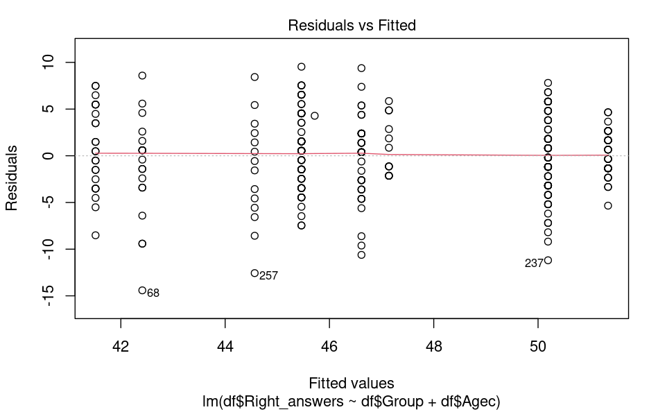

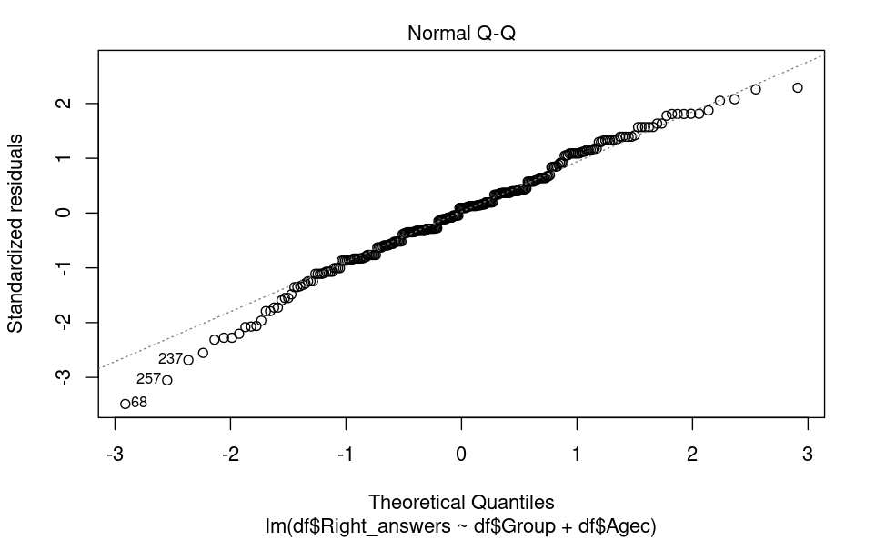

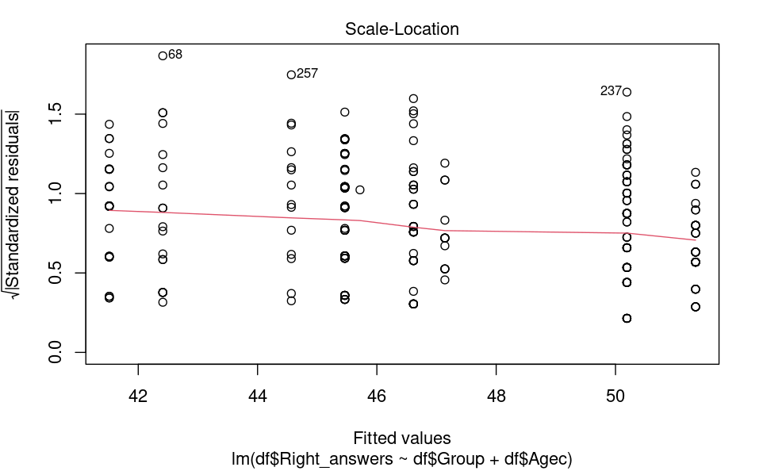

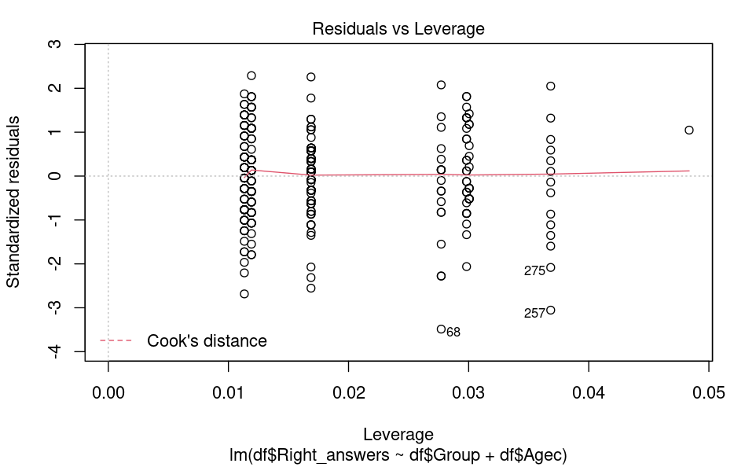

```r
plot(res2)
```

Distance de cook parfaite sauf pour un point qui dépasse $ (p+1)/n = 2(i+j)/n = 0.043$. Ce points et le sujet qui était le seul dans son groupe, car il est seul il attire fortement les poids.

Q-plot ok décroche un peu sur les bord, variance ok

# Question 8

```r
?predict.lm
predict(res2, data.frame(Group="Control", Agec="<40"), interval="confidence") # IC à 95%
predict(res2, data.frame(Group="Control", Agec="<40"), interval="prediction") # IC à 95% + la variance de l'erreur
```

[output not shown]

# Question 9

```r
emmeans(res2, ~Group)
```

```
 Group   emmean    SE  df lower.CL upper.CL
 Bipolar   44.8 0.404 272     44.0     45.6
 Control   49.6 0.417 272     48.7     50.4
 UD        43.9 0.711 272     42.5     45.3

Results are averaged over the levels of: Agec
Confidence level used: 0.95
```

Dans ce cas, ça utilise une moyenne marginale, on vas faire comme si on avait une répartition de sujet parfaite dans chaque classe. Ca se construit en pondérant les moyenne en m’étant le même coef pour chaque classe d’age.

La moyenne de UD change beaucoup car peu de jeune dans ce groupe, il faut compenser l’impact des score moins bon des vieux.

Ici on veut garder l’information de l’age dans la predition. Car sinon on pourait juste faire une anova à 1 facteur.

# Question 11

On cherche à savoir si $\alpha_{BD} = \alpha _{UD}$. On vas tester $H_0 = \{\alpha_{BD} = \alpha_{UD}\}, H_1 = \{\alpha_{BD} \neq \alpha{UD}\}$. C’est un test de constraste. $1*\alpha_{BD} + 0*\alpha_{ctrl} - 1*\alpha_{UD} = 0$

```r
c1 = c(1,0,-1)
contrast(emmeans(res2, ~Group), list(Group=c1)) # Pas d'écart significatif
```

```
 contrast estimate    SE  df t.ratio p.value
 Group       0.897 0.841 272   1.066  0.2872

Results are averaged over the levels of: Agec
```

# Question 11

```r
contrast(emmeans(res2, ~Group), "pairwise", adjust="Tukey")
```

```
 contrast          estimate    SE  df t.ratio p.value
 Bipolar - Control   -4.729 0.545 272  -8.680  <.0001
 Bipolar - UD         0.897 0.841 272   1.066  0.5358
 Control - UD         5.625 0.854 272   6.590  <.0001

Results are averaged over the levels of: Agec
P value adjustment: tukey method for comparing a family of 3 estimates
```

```r
cat("\n\n\n")
```

```r
contrast(emmeans(res2, ~Group), "pairwise", adjust="Bonferroni")
```

```
 contrast          estimate    SE  df t.ratio p.value
 Bipolar - Control   -4.729 0.545 272  -8.680  <.0001
 Bipolar - UD         0.897 0.841 272   1.066  0.8616
 Control - UD         5.625 0.854 272   6.590  <.0001

Results are averaged over the levels of: Agec
P value adjustment: bonferroni method for 3 tests
```

Ici ça fait plusieurs (3) test into une p-value je crois, ce qui explique la différence de p-value avec le test question d’avant.